# Satellite Image Classification

## Deep dive into computer vision

Using CNNs for transfer learning

This notebook illustrates how to classify satellite images for disaster detection. Since we do not have a lot of data available of disaster images we use transfer learning to learn initial features of satellite images and then extend it to support disaster images.

The explanation for this notebook has been inspired from [https://towardsdatascience.com/transfer-learning-using-differential-learning-rates-638455797f00]

### So what is transfer learning?

It is the process of using the knowledge learned in one process/activity and applying it to a different task. Let us take a small example, a player who is good at chess can apply that knowledge in learning how to play checkers.

[figure not shown]

### How to do it?

We take a pretrained network and and train only the newly added layers. This works well when the tasks are related to each other and you have a small amount of data.

The following steps describe how to load the dataset and a pretrained model. The dataset we are using is from the kaggle competition [https://www.kaggle.com/c/planet-understanding-the-amazon-from-space/data]

You may notice that the data available from this kaggle competition are general satellite images. So how does this connect to disaster images?

Trust me, there's a connection

```python
%reload_ext autoreload
%autoreload 2
%matplotlib inline
```

```python
import sys
import torch
import torchvision.transforms as transforms
```

```python
fast_ai_path = '/home/ubuntu/asir/fastai/'
```

```python
sys.path.append(fast_ai_path)
```

```python
from fastai.conv_learner import *
```

```python
from fastai.plots import *
```

```python
DATA_PATH = '/home/ubuntu/asir/sate-class/data/'
```

```python
f_model = resnet34
sz = 64
bs = 64
```

```python
#  Prepare data Validation set
label_csv = f'{DATA_PATH}train_v2.csv'
n = len(list(open(label_csv)))-1 #total number of images
val_idxs = get_cv_idxs(n) #it will return 20% indexes from training data set to used for val data
```

```python
from courses.dl1.planet import f2, opt_th
```

```python
metrics = [f2]
```

```python
def get_data(sz, bs):
    """Returns data generator"""
    tfms =  tfms_from_model(f_model, sz, aug_tfms=transforms_top_down, max_zoom=1.05)
    return ImageClassifierData.from_csv(DATA_PATH, 'train-jpg', label_csv, bs, tfms, suffix='.jpg', val_idxs=val_idxs, test_name='test-jpg')
data = get_data(sz, bs)
```

```python
learn = ConvLearner.pretrained(f_model, data, metrics=metrics)
```

Now that we have created a network and loaded our data. We can start training. Notice that the pretrained network we are using has only been trained on general images.

It has never seen satellite images. Hence, the power of transfer learning

The achitecture for your CNN is a Deep Residual Network [Reference: https://arxiv.org/abs/1512.03385]

```python
lr=0.2
#data = get_data(64, 16) #data generator for batch size=64, image size=64x64
#learn = ConvLearner.pretrained(f_model, data, metrics=metrics)
learn.fit(lr, 3, cycle_len=1, cycle_mult=2)
```

```
[0.      0.14499 0.13412 0.87962]
[1.      0.13942 0.12814 0.88809]
[2.      0.13532 0.12652 0.8877 ]
[3.      0.13428 0.12524 0.88971]
[4.      0.13316 0.12333 0.89218]
[5.      0.12772 0.12196 0.89313]
[6.      0.12641 0.12102 0.89463]
```

### "differential learning rates"

Once we have a decent classifier trained we want to use something called "differential learning rates" to not just train our last layer in the network but all of them.

Differential learning rates mean that we use different learning rates for different parts of the network during our training. The idea is to divide the layers into various layer groups and set different learning rate for each group so that we get ideal results.

### Why is this helpful?

So we don't want to change the initial layers too much but middle layers will have knowledge of the complex features that might help our task.

```python
lrs = [lr/9, lr/3, lr]
learn.unfreeze()
learn.fit(lrs, 3, cycle_len=1, cycle_mult=2)
```

```
[0.      0.11484 0.10816 0.90639]
[1.      0.11061 0.10116 0.91519]
[2.      0.10401 0.09966 0.91497]
[3.      0.10681 0.10178 0.91467]
[4.      0.10086 0.10073 0.91335]
[5.      0.09407 0.09797 0.91611]
[6.      0.09395 0.09667 0.91808]
```

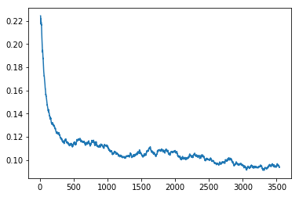

```python
learn.sched.plot_loss()
```

```python
#train for image size128x128
#learn.set_data(get_data(128, 64))

#learn.freeze()
#learn.fit(lr, 3, cycle_len=1, cycle_mult=2)

#learn.unfreeze()
#learn.fit(lr, 3, cycle_len=1, cycle_mult=2)
```

```python
#learn.set_data(get_data(256, 64))

#learn.freeze()
#learn.fit(lr, 3, cycle_len=1, cycle_mult=2)

#learn.unfreeze()
#learn.fit(lr, 3, cycle_len=1, cycle_mult=2)
```

```python
learn.save('resnet34.weights.1')
```

```python
learn.load('resnet34.weights.1')
```

### Testing

After we've finished training we can look out test results. One of the cool things we do during testing is that we apply "test time augmentation." What this does is basically changes the image size, angle, shape etc and tries to fool the network into thinking its a different image.

How is this useful? Remember we said we are short on data. If we use a lot of images for training we'll have even less for testing. Using "test time augmentation" we can use a slightly modified different version of the same image. Its also useful because it lets us test whether a slightly modified image can give us the same result hence, confirming the robustness of the network.

```python
test_tta = learn.TTA(is_test=True)
```

```python
test_fnames = data.test_ds.fnames

for i in range(len(test_fnames)):
    test_fnames[i] = test_fnames[i].split("/")[1].split(".")[0]

classes = np.array(data.classes, dtype=str)
res = [" ".join(classes[np.where(pp > 0.2)]) for pp in test_tta[0]]

test_frame = pd.DataFrame(data=res)

test_frame.columns = ["tags"]

test_frame.insert(0, 'image_name', test_fnames)
```

```python
test_frame.head()
```

|  | image_name | tags |
| --- | --- | --- |
| 0 | test_16388 | clear primary |
| 1 | test_31959 | clear primary |
| 2 | test_12330 | clear primary |
| 3 | test_33928 | agriculture clear cultivation primary road water |
| 4 | test_36768 | clear primary |

```python
val_tta = learn.TTA()
```

```python
valid_fnames = data.val_ds.fnames

for i in range(len(valid_fnames)):
    valid_fnames[i] = valid_fnames[i].split("/")[1].split(".")[0]

classes = np.array(data.classes, dtype=str)
res = [" ".join(classes[np.where(pp > 0.2)]) for pp in val_tta[0]]

val_frame = pd.DataFrame(data=res)

val_frame.columns = ["tags"]

val_frame.insert(0, 'image_name', valid_fnames)
```

```python
val_frame.head()
```

|  | image_name | tags |
| --- | --- | --- |
| 0 | train_1 | agriculture clear cultivation primary road water |
| 1 | train_1000 | partly_cloudy primary |
| 2 | train_10002 | agriculture clear habitation primary road |
| 3 | train_10008 | artisinal_mine clear primary road water |
| 4 | train_10017 | agriculture clear habitation primary road |

```python
def plot_img(fnames,frame, figsize=(16,8), rows=1, data_path=DATA_PATH):
    f = plt.figure(figsize=figsize)
    for name in range(len(fnames)):
        img = PIL.Image.open(data_path+fnames[name]+'.jpg')
        tag = frame.loc[frame['image_name'] == fnames[name]]['tags'].iloc[0]
        sp = f.add_subplot(rows, len(fnames)//rows, name+1)
        sp.set_title(tag, fontsize=10)
        sp.axis('Off')
        #print(tag)
        plt.imshow(img)
```

### Output

And...Voila!! We have labelled satellite images!! In a few lines of code with limited data we have trained a network (that had never seen satellite images) to classify with a decent accuracy.

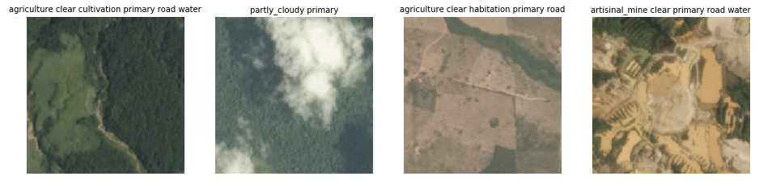

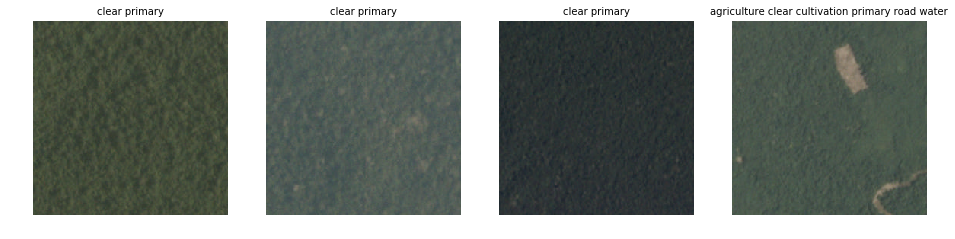

```python
plot_img(valid_fnames[:4],val_frame data_path=DATA_PATH+'train-jpg/')
plot_img(test_fnames[:4], submission, data_path=DATA_PATH+'test-jpg/')
```

Still nothing about disaster though??

We're getting there. I promise its all related

### Satellite Images of Floods

So now we prep out satellite images of disaster, particularly we'll be looking at floods. Which are even less in number!

Again we'll try to use the power of transfer learning to accomplish this task.

```python
PATH = '/home/ubuntu/asir/sate-class/data/images_labeled/'
```

```python
#  Prepare data Validation set
label_csv = f'{PATH}image_labels.csv'
n = len(list(open(label_csv)))-1 #total number of images
val_idxs = get_cv_idxs(n) #it will return 20% indexes from training data set to used for val data
```

```python
def get_data(sz, bs):
    """Returns data generator"""
    tfms =  tfms_from_model(learn.models.f, sz, aug_tfms=transforms_top_down, max_zoom=1.05)
    return ImageClassifierData.from_csv(PATH, 'train', label_csv, bs, tfms, suffix='.jpg', val_idxs=val_idxs, test_name='test')
small_data = get_data(64, 5)
```

### New Network

Similar to before we initialize a pretrained network. But this time we start from the network we just trained. The idea is that now that we have a network that understands features of satellite images in general, we can use it to pick up features of floods as well.

```python
learn_new = ConvLearner.pretrained(learn.models.f,small_data, metrics=metrics)
```

Similar training techniques as before

```python
lr=0.2
learn_new.fit(lr, 3, cycle_len=1, cycle_mult=2)
```

```
[0.      0.85582 0.70415 0.77593]
[1.      0.81165 0.66145 0.79915]
[2.      0.76139 0.66933 0.79915]
[3.      0.7221  0.60217 0.82077]
[4.      0.65776 0.54006 0.86167]
[5.      0.61014 0.52846 0.87427]
[6.      0.57234 0.51439 0.87465]
```

```python
lrs = [lr/9, lr/3, lr]
learn_new.unfreeze()
learn_new.fit(lrs, 3, cycle_len=1, cycle_mult=2)
```

```
[0.      0.62834 2.1607  0.59882]
[ 1.       0.61793 13.43594  0.49179]
[ 2.       0.74112 10.4612   0.41359]
[ 3.       0.7024  10.36163  0.48793]
[4.      0.71312 7.40117 0.77616]
[5.      0.6967  5.87676 0.77513]
[6.      0.69466 4.32261 0.77513]
```

### Testing on Disaster Images

Finally we're ready try out our network on the satellite image data of disasters.

```python
new_test_tta = learn_new.TTA(is_test=True)
```

```python
new_test_fnames = small_data.test_ds.fnames

#for i in range(len(new_test_fnames)):
#    new_test_fnames[i] = new_test_fnames[i].split("/")[1].split(".")[0]

classes = np.array(small_data.classes, dtype=str)
res = [" ".join(classes[np.where(pp > 0.7)]) for pp in new_test_tta[0]]

new_test_frame = pd.DataFrame(data=res)

new_test_frame.columns = ["tags"]

new_test_frame.insert(0, 'image_name', new_test_fnames)
```

```python
new_test_frame.head()
```

|  | image_name | tags |
| --- | --- | --- |
| 0 | 20 | afterFlood clear habitation water |
| 1 | 11 | clear habitation road water |
| 2 | 17 | afterFlood agliculture clear cultivation flood... |
| 3 | 21 | afterFlood agliculture clear cultivation flood... |
| 4 | 19 | beforeFlood clear habitation road |

### Results

With very few instances of training (mostly scraped by us from the internet) we have trained a model to identify floods.

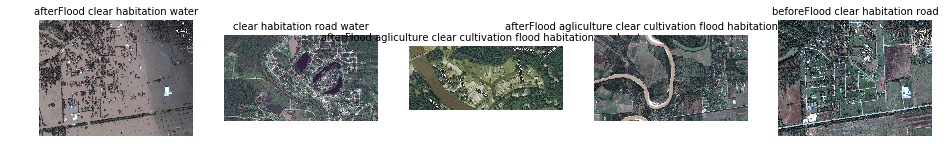

```python
plot_img(new_test_fnames[:5], new_test_frame.head(),data_path=(PATH+'test/'))
```

This notebook was inspired by the MOOC [fast.ai] Part 1 Thank you!!

This is just the beginning, we hope to extend this idea detect not only floods but also earthquakes, eruptions, hurricanes and other man-made or natural disasters and help areas with weak infrastructure where satellite images are the fastest source of information.